# Базовая визуализация данных в R. Часть 1

Author

Oksana Plastinina

```r
library(tidyverse)
library(patchwork)
library(gghighlight)
```

```r
hogwarts <- read_csv("data/hogwarts_2025.csv")
```

```r
#тема ко всему документу
theme_set(theme_bw())

#частоиспользуемые вектора
house_names <- c("Gryffindor" =  "Гриффиндор",
      "Hufflepuff" = "Пуффендуй",
      "Ravenclaw" = "Когтевран",
      "Slytherin" = "Слизерин")
house_colours <- c("Gryffindor" = "#C50000",
                "Hufflepuff" = "#ECB939",
                "Ravenclaw" = "#41A6D9",
                "Slytherin" = "#1F5D25")
bloodStatus_values <- c( 'half-blood' = "lightblue4",
                "muggle-born" = "sienna3",
                "pure-blood" = "mediumpurple4")
bloodStatus_labels <- c(
      'half-blood' = "Полукровка",
      "muggle-born" = "Маглорожденный",
      "pure-blood" = "Чистокровка")
```

### 1. Распределение числа студентов по курсу в Хогвартсе

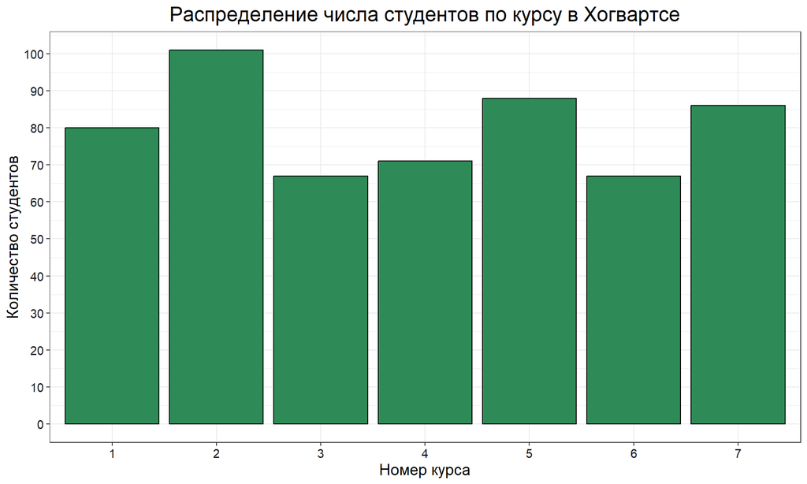

```r
ggplot(hogwarts)+
  geom_bar(aes(x = as.factor(course)), fill = 'seagreen', colour = 'black')+
  labs(
    title = 'Распределение числа студентов по курсу в Хогвартсе',
    x = 'Номер курса',
    y = 'Количество студентов'
       )+
  scale_y_continuous(breaks = seq(0,100,10))+
  theme(
    plot.title = element_text(hjust = 0.5, size =18),
    axis.title = element_text(size = 14),
    axis.text = element_text(size = 11, colour = 'grey10')
  )
```

### 2. Распределение студентов разного происхождения внутри факультетов

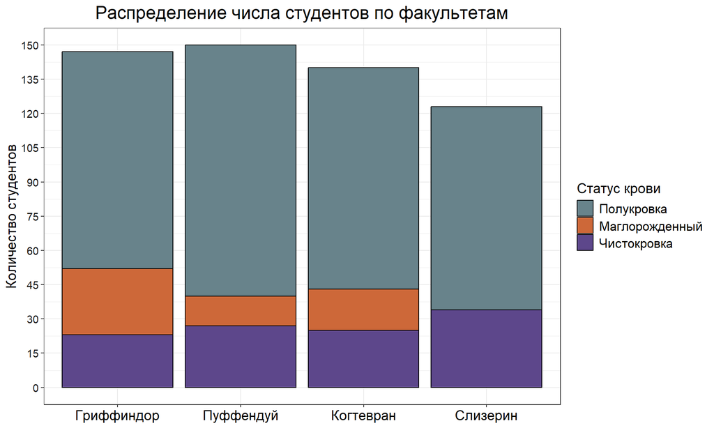

```r
ggplot(hogwarts)+
  geom_bar(aes(x = as.factor(house), fill = bloodStatus), colour = 'black')+
  labs(
    title = 'Распределение числа студентов по факультетам',
    x = NULL,
    y = 'Количество студентов' )+
  scale_fill_manual(
    name = 'Статус крови',
    values = bloodStatus_values,
    labels = bloodStatus_labels
    )+
  scale_x_discrete(
    labels = house_names
  )+
  scale_y_continuous(breaks = seq(0,150,15))+
  theme(
    plot.title = element_text(hjust = 0.5, size =18),
    axis.title = element_text(size = 14),
    axis.text.y = element_text(size = 11, colour = 'grey10'),
    axis.text.x = element_text(size = 14, colour = 'black'),
    legend.title = element_text(size = 14),
    legend.text = element_text(size = 13)
  )
```

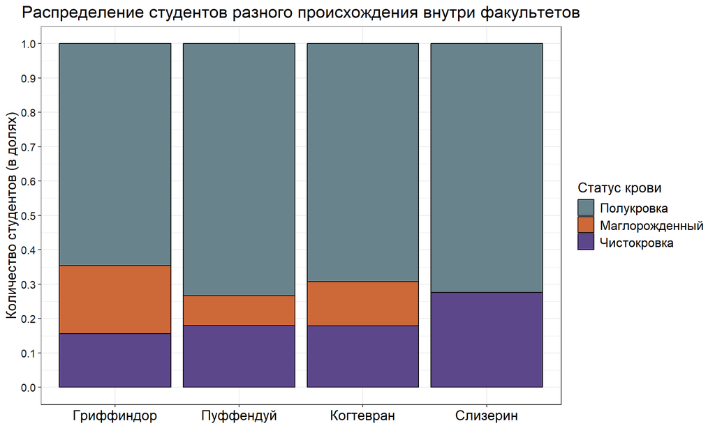

```r
bloodStatus_hogwarts <- ggplot(hogwarts)+
  geom_bar(aes(x = as.factor(house), fill = bloodStatus), colour = 'black', position = 'fill', )+
  labs(
    title = 'Распределение студентов разного происхождения внутри факультетов',
    x = NULL,
    y = 'Количество студентов (в долях)' )+
  scale_fill_manual(
    name = 'Статус крови',
    values = bloodStatus_values,
    labels = bloodStatus_labels
    )+
  scale_x_discrete(
    labels = house_names
  )+
  scale_y_continuous(breaks = seq(0,1,0.1))+
  theme(
    plot.title = element_text(hjust = 0.5, size =17),
    axis.title = element_text(size = 14),
    axis.text.y = element_text(size = 11, colour = 'grey10'),
    axis.text.x = element_text(size = 14, colour = 'black'),
    legend.title = element_text(size = 14),
    legend.text = element_text(size = 13)
  )

bloodStatus_hogwarts
```

Доли волшебников разного происхождения на каждом из факультетов, за некотрым исключением, примерно равны. Полукровки составляют наибольшую долю волшебников на каждом из факультетов (от 65%). Чистокровки также есть на кадом из факультетов, доля их числа составляет примерно 15 и 25% (Гриффиндор и Слизерин соответственно). Маглорожденные волшебники не учатся на Слизерине, доли их числа составляют примерно 8 и 20% (Пуффендуй и Гриффиндор соответсвенно).

### 3. Распределение набранных баллов студентов факультетов за третью неделю обучения

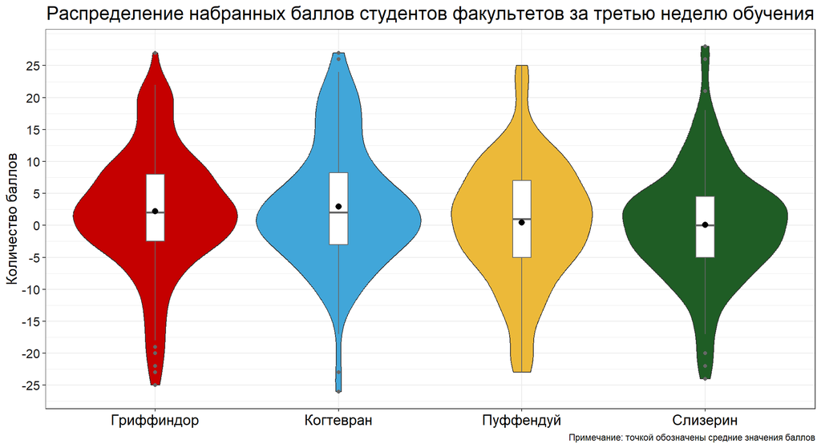

```r
hogwarst_week3 <- hogwarts %>%
  group_by(house) %>%
  arrange(week_3, result, house) %>%
  summarise(
    meadian_w3 = median(week_3,na.rm = T),
    mean_w3 = mean(week_3,na.rm = T)
  )

hogwarts_house_result <- hogwarts %>%
  ggplot()+
  #здесь при построении графика сразу упорядочиваем в порядке убывания медианного балла
  geom_violin(aes(x = fct_reorder(house, week_3, .desc = TRUE), y = week_3, fill = house))+
  geom_boxplot(aes(x = house, y = week_3), width = 0.1, colour = 'grey40')+
  geom_point(data=hogwarst_week3, aes(x=house, y = mean_w3), shape = 16, size = 2.5)+
  labs(
    title = 'Распределение набранных баллов студентов факультетов за третью неделю обучения',
    caption = 'Примечание: точкой обозначены средние значения баллов',
    x = NULL,
    y = 'Количество баллов'
  )+
  scale_fill_manual(
    values = house_colours)+
  scale_x_discrete(labels = house_names)+
  scale_y_continuous(breaks = seq(-25,25,5))+
  theme(
    plot.title = element_text(hjust = 0.5, size = 18),
    axis.title = element_text(size = 14),
    axis.text.x = element_text(size =14, colour = 'black'),
    axis.text.y = element_text(size = 12, colour = 'grey10'),
    legend.position = 'none'
  )

hogwarts_house_result
```

### 4. Распределение баллов за экзамен по полету на метле студентами разных курсов

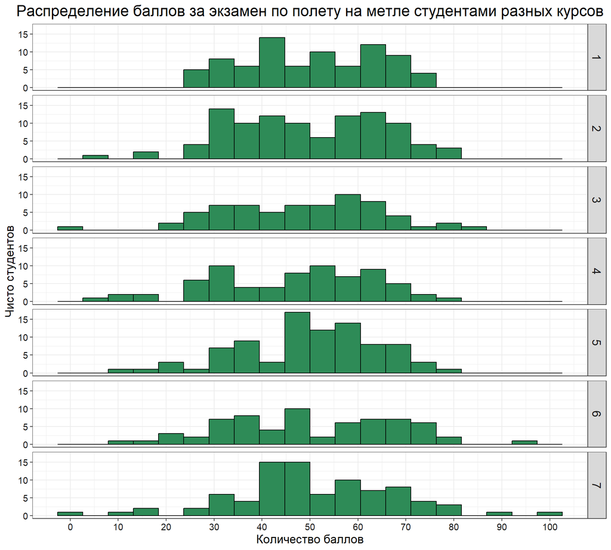

```r
hogwarts %>%
  ggplot()+
  geom_histogram(aes(x = `Flying exam`), fill = 'seagreen', colour = 'black', bins = 20)+
  facet_grid(as.factor(course)~.)+
  labs(
    title = 'Распределение баллов за экзамен по полету на метле студентами разных курсов',
    x = 'Количество баллов',
    y = 'Чисто студентов'
  )+
  scale_x_continuous(breaks = seq(0,100,10))+
  theme(
    plot.title = element_text(hjust = 0.5, size = 18),
    axis.title = element_text(size = 14),
    axis.text = element_text(size = 11, colour = 'grey10'),
    strip.text = element_text(size = 14)
  )
```

### 5. Взаимосвязь суммарнного балла студента за год и его оценки за экзамен по травологии

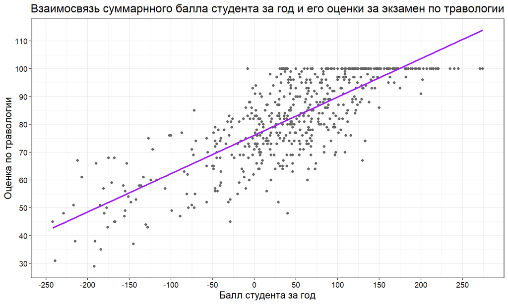

```r
ggplot(hogwarts, aes(x = result, y = `Herbology exam`))+
  geom_point(shape = 19, colour = 'grey40')+
  scale_y_continuous(breaks = seq(20, 150, 10))+
  scale_x_continuous(breaks = seq(-300,300,50))+
  labs(title = 'Взаимосвязь суммарнного балла студента за год и его оценки за экзамен по травологии',
       y = 'Оценка по травологии',
       x = 'Балл студента за год')+
  geom_smooth(method = 'lm', se = FALSE, colour = 'purple')+
  theme(
    plot.title = element_text(hjust = 0.5, size = 16),
    axis.title = element_text(size = 14),
    axis.text = element_text(size = 11, colour = 'grey10')
  )
```

Количество набранных студентом баллов за год и его оценка по травологии положительно коррелируют, т.е. чем выше балл, тем выше оценка. Большая часть студентов получила суммарный балл >-50 и оценку по травологии >65. При этом наблюдаются аномальные баллы, т.е. есть студенты, получившие высокую отметку за экзамен (>65) и низкий суммарный балл (<-50).

### 6. Взаимосвязь суммарнного балла студента за год и его оценки за экзамены

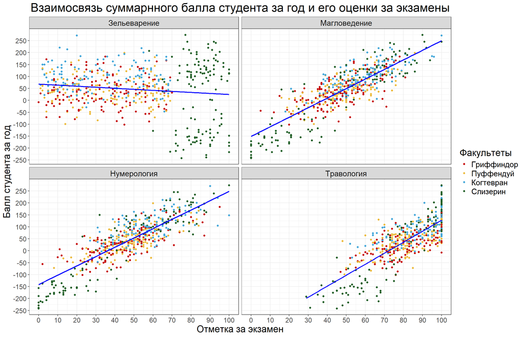

```r
hogwarts %>%
  select(id, house, result, `Herbology exam`, `Muggle studies exam`, `Arithmancy exam`, `Potions exam`) %>%
  rename('Травология' = `Herbology exam`, 'Магловедение' = `Muggle studies exam`, 'Нумерология' = `Arithmancy exam`, 'Зельеварение'= `Potions exam`)  %>%
  pivot_longer(c('Травология', 'Магловедение', 'Нумерология', 'Зельеварение'), names_to = 'exams', values_to = 'score') %>%
  ggplot(aes(y = result, x = score))+
  geom_point(aes(colour = house)) +
  facet_wrap(.~exams, ncol = 2, )+
  labs(title = 'Взаимосвязь суммарнного балла студента за год и его оценки за экзамены',
       x = 'Отметка за экзамен',
       y = 'Балл студента за год')+
  scale_colour_manual( name = 'Факультеты',
    values = house_colours,
    labels = house_names) +
  scale_x_continuous(breaks = seq(0,100,10))+
  scale_y_continuous(breaks = seq(-250,300,50))+
  geom_smooth(method = 'lm', se = F, colour = 'blue')+
  theme(
    plot.title = element_text(hjust = 0.5, size = 23),
    axis.title = element_text(size = 18),
    axis.text = element_text(size = 13),
    legend.title = element_text(size = 18),
    legend.text = element_text(size = 15),
    strip.text = element_text(size = 15)
  )
```

Для всех экзаменах, кроме зельеварения, можно говорить о положительной корреляции суммарного балла студента за год и его отметки за экзамен. Отметка по экзамену по зельеварению с суммарным баллом не коррелирует.

Отметки студентов разных факультетов за экзамены распредлены равномерно, за исключением экзамена по зельеварению, где отметку >70 получили только студенты Слизерина (практически все). При этом самые низкие отметки по остальным экзаменом принадлежат примущественно студентам этого факультета <30 по магловедению, <20 по нумерологии, <60 по травологии.

Лучше всего студенты всех факультетов сдавали травологию, никто не получил отмеку, ниже примерно 30 баллов.

### 7. Взаимосвязь суммарных баллов студентов разных факультетов за год и их оценки за экзамены

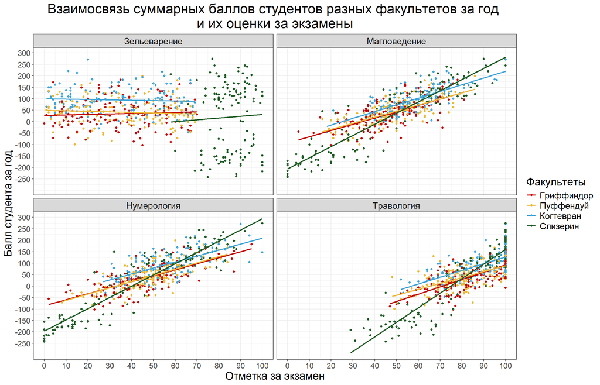

```r
hogwarts %>%
  select(id, house, result, `Herbology exam`, `Muggle studies exam`, `Arithmancy exam`, `Potions exam`) %>%
  rename('Травология' = `Herbology exam`, 'Магловедение' = `Muggle studies exam`, 'Нумерология' = `Arithmancy exam`, 'Зельеварение'= `Potions exam`)  %>%
  pivot_longer(c('Травология', 'Магловедение', 'Нумерология', 'Зельеварение'), names_to = 'exams', values_to = 'score') %>%
  ggplot(aes(y = result, x = score, colour = house))+
  geom_point() +
  facet_wrap(.~exams, ncol = 2)+
  geom_smooth(method = 'lm', se = F)+
  labs(title = 'Взаимосвязь суммарных баллов студентов разных факультетов за год \nи их оценки за экзамены',
       x = 'Отметка за экзамен',
       y = 'Балл студента за год')+
  scale_colour_manual( name = 'Факультеты',
    values = house_colours,
    labels = house_names) +
  scale_x_continuous(breaks = seq(0,100,10))+
  scale_y_continuous(breaks = seq(-250,300,50))+
  theme(
    plot.title = element_text(hjust = 0.5, size = 23),
    axis.title = element_text(size = 18),
    axis.text = element_text(size = 13),
    legend.title = element_text(size = 18),
    legend.text = element_text(size = 15),
    strip.text = element_text(size = 15)
  )
```

Группировка линий трендов по факультетам позволила рассмотреть дополнительные характеристики взаимосвязей годового балла студента и его отметкой за 4 представленных экзамена. А именно: 1) взаимосвязь суммарного балла студентов всех факультетов на экзменах, исключая зельеварение, есть и является положительной; 2) при этом, угол наклона линии тренда факультета Слизерина для всех экзменов, исключая зельеварение, наибольший, что говорит о сравнительно бOльшей взаимосвязи суммарнного балла и соответсвующего экзамена; 3) углы наклонов линий трендов (и соответственно взаимосвязи) остальных трех факультетов для всех экзменов, исключая зельеварение, схожи. При этом каждый отдельный студент Когтеврана набрал за год бОльшее количество баллов в сравнении с отдельными студентами Гриффиндора и Пуффендуя; 4) ни для одного из факультетов не обнаружена корреляция суммарного балла и отметки за экзамен по зельеварению.

### 8. Распределение отметок по экзаменам по прорицанию и защите от темных искусств

```r
hogwarts_2exams <- hogwarts %>%
  rename('Экзамен по защите от темных искусств' = `Defence against the dark arts exam`, 'Экзамен по прорицанию' = `Divinations exam`) %>%
  pivot_longer(c('Экзамен по защите от темных искусств', 'Экзамен по прорицанию'), values_to = 'score', names_to = 'exams')
```

```r
hist_darkdef_diviation <- hogwarts_2exams %>%
  ggplot(aes(x = score, fill = exams))+
  geom_histogram(alpha = 0.5, colour = 'black', bins = 20)+
  labs(
    x = 'Балл за экзамен',
    y = 'Количество учеников'
  )+
  scale_x_continuous(breaks = seq(0,100,10))+
  scale_y_continuous(breaks = seq(0,150,20))+
  scale_fill_manual(
    name = NULL,
    values = c('Экзамен по защите от темных искусств' = 'mediumorchid4',
               'Экзамен по прорицанию' = 'peru')
  )+
  theme(
    plot.title = element_text(hjust = 0.5),
    legend.text = element_text(size = 15),
    axis.title = element_text(size = 17),
    axis.text.y = element_text(size = 11),
    axis.text.x = element_text(size = 11),
    legend.position = 'bottom',
    legend.justification = 'centre',
    legend.direction = 'horizontal'
  )
```

```r
boxplot_darkdef_diviation <- hogwarts_2exams %>%
  ggplot()+
  geom_boxplot(aes(y = score, x = exams, fill = exams), alpha = 0.7)+
  labs(
    x = NULL,
    y = 'Балл за экзамен'
  )+
  scale_y_continuous(breaks = seq(0,100,10))+
  scale_fill_manual(
    values = c('Экзамен по защите от темных искусств' = 'mediumorchid4',
               'Экзамен по прорицанию' = 'peru')
  )+
  theme(
    plot.title = element_text(hjust = 0.5 ),
    legend.position = 'none',
    axis.title = element_text(size = 17),
    axis.text.y = element_text(size = 11),
    #axis.text.x = element_text(size = 15),
    #уберем, тк в легенде четку обозначена цветовая группировка
    axis.text.x = element_blank()
  )
```

```r
jitter_darkdef_diviation <- hogwarts_2exams %>%
  ggplot()+
geom_jitter(aes(x = exams, y = score, colour = exams))+
  labs(
    x = NULL,
    y = 'Балл за экзамен'
  )+
  scale_y_continuous(breaks = seq(0,100,10))+
 scale_color_manual(
    values = c('Экзамен по защите от темных искусств' = 'mediumorchid4',
               'Экзамен по прорицанию' = 'peru')
  )+
  theme(
    plot.title = element_text(hjust = 0.5 ),
    legend.position = 'none',
    axis.title = element_text(size = 17),
    axis.text.y = element_text(size = 11),
    #axis.text.x = element_text(size = 15),
     #уберем, тк в легенде четку обозначена цветовая группировка
    axis.text.x = element_blank()
  )
```

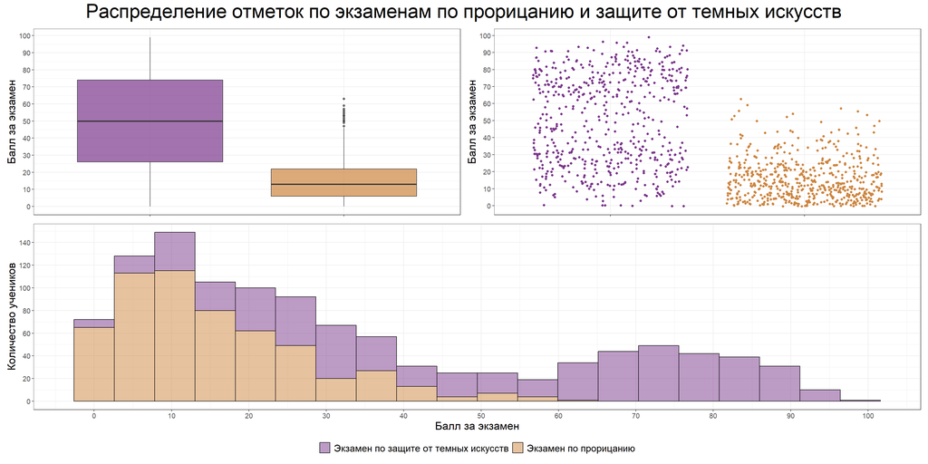

```r
(boxplot_darkdef_diviation | jitter_darkdef_diviation)/
hist_darkdef_diviation+
    plot_annotation(
    title = "Распределение отметок по экзаменам по прорицанию и защите от темных искусств",
    theme = theme(plot.title = element_text(hjust = 0.5, size = 30)))
```

Распредления баллов за два экзамена различаются. В счучае экзамена по защите от темных исскуств студенты получили отметки во всем диапазоне 0-100 баллов, при этом чаще получали отметки в диапазоне 0-40, реже - 40-60. Медианное значение отметки по этому экзамену - 50. В случае экзамена по прорицанию отметки получали в диапазоне 0-60. Немногие студенты получили балл >40. Медианное значение отметки по этому экзамену ~13.

### 9. Анализ среднего балла по зельеварению студентов с различным происхождением

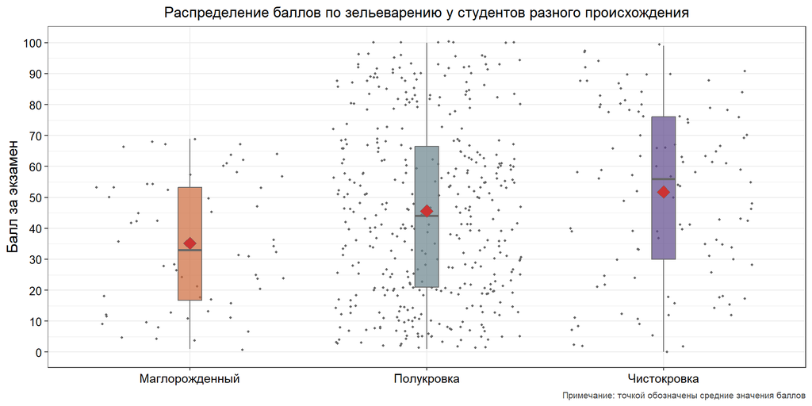

```r
hogwarts_potionsmean_bloodstatus <- hogwarts %>%
  mutate(bloodStatus = factor(bloodStatus, level = c ('muggle-born', 'half-blood', 'pure-blood'))) %>%
  group_by(bloodStatus) %>%
  summarise(`Среднее по зельеварению` = mean(`Potions exam`))

hogwarts %>%
  #упорядочиваем переменную происхождения
  mutate(bloodStatus = factor(bloodStatus, level = c ('muggle-born', 'half-blood', 'pure-blood'))) %>%
  ggplot(aes(x = bloodStatus, y = `Potions exam`))+
  geom_jitter(size = 0.7, shape = 21, colour = 'grey40', fill = 'grey40')+
  geom_boxplot(aes(fill = bloodStatus),colour = 'grey40', width = 0.1, alpha = 0.7)+
  geom_point(data = hogwarts_potionsmean_bloodstatus, aes(x=bloodStatus, y = `Среднее по зельеварению`), size = 4, shape = 23, fill = 'brown3', colour = 'grey40')+
  labs(
    title = 'Распределение баллов по зельеварению у студентов разного происхождения',
    x = NULL,
    y = 'Балл за экзамен',
    caption = 'Примечание: точкой обозначены средние значения баллов'
  )+
  scale_fill_manual(values = bloodStatus_values)+
  scale_x_discrete(labels = bloodStatus_labels)+
  scale_y_continuous(breaks = seq(0,100,10))+
  theme(
    plot.title = element_text(hjust = 0.5 ),
    axis.text.x = element_text(color = "black", size = 11),
    axis.text.y = element_text(color = "black", size = 10),
    axis.title = element_text(size = 13),
    legend.position = 'none',
    plot.caption = element_text(size = 8, colour = 'grey25')
  )
```

Полукровки и чистокровки получали баллы по экзамену по зельеварению во всем диапазоне значений (0-100), маглорожденные волшебники не получили оченок выше 70 баллов и имеют наименьший средний балл по экзамену. При этом разрыв баллов между группами небольшой, ~20 баллов. Медианные значения примерно равны средним.

Чтобы найти объяcнения полученным результатам, обратимся к графикам распределения баллов по зельеварению у студентов разных факультетов и распределению студентов разного происхождения внутри факультетов. Из первого графика мы видим, что отметки по зельеварению >70 получили только студенты Слизерина, при этом, как видно на втором графике, маглорожденные студенты не учатся на этом факультете. Т.е. и значения баллов >70 полукровок и чистокровок соответствуют только студентам Слизерина. Это объясняет отсутвие баллов >70 только у маглорожденных студентов.

Распределение cуммарных баллов за год у студентов разного происхождления показывает, маглорожденные студенты не учатся сильно хуже остальных, средние глобально не различаются, маглорожденные не получили самых высоких баллов, но и не получали баллов ниже -100. Студенты Слизерина же не отличаются исключительно высокими баллами (см. Распределение cуммарных баллов за год у студентов разных факультетов), их студенты скорее разделились на две группы: те, кто получил >50 и <-50 баллов (если смотреть на график задания 12 Распределение числа баллов у студентов различных факультетов Хогвартса в 2024-2025 учебном году, то видно, что это группы, различные по полу). Т.е. студенты Слизерина не самые преуспевающие в школе, а маглорожденные студенты не самые отстающие.

Графики ‘Распределения баллов по экзаменам у маглорожденных волшебников и студентов Слизерина’ и ‘Распределения баллов по экзаменам у студентов разных факультетов’ показывают, что такие значительные различия баллов между студентами факультета Слизерина и маглорожденными студентами и студентами разных факультетов наблюдаются только для экзамена по зельеварению.

Таким образом можно сделать вывод, что экзамен по зельеварению оценивался предвзято, в пользу студентов Слизерина, вне зависимости от происхождения студента.

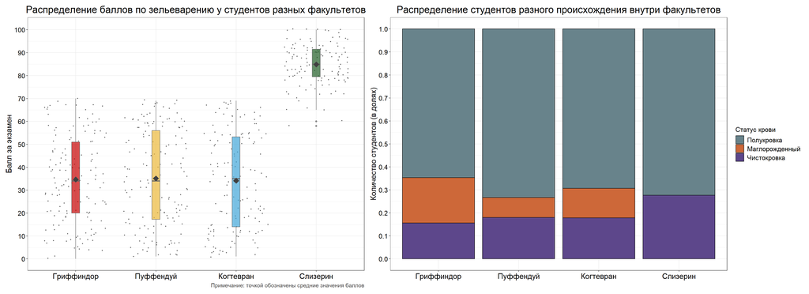

```r
hogwarts_potionsmean_house <- hogwarts %>%
  group_by(house) %>%
  summarise(`Среднее по зельеварению` = mean(`Potions exam`))

Hogwarts_potion_house <- hogwarts %>%
  ggplot(aes(x = house, y = `Potions exam`))+
  geom_jitter(size = 0.7, shape = 21, colour = 'grey40', fill = 'grey40')+
  geom_boxplot(aes(fill = house),colour = 'grey40', width = 0.1, alpha = 0.7)+
  geom_point(data = hogwarts_potionsmean_house, aes(x=house, y = `Среднее по зельеварению`), size = 4, shape = 23, fill = 'grey25', colour = 'grey40')+
  labs(
    title = 'Распределение баллов по зельеварению у студентов разных факультетов',
    x = NULL,
    y = 'Балл за экзамен',
    caption = 'Примечание: точкой обозначены средние значения баллов'
  )+
  scale_fill_manual(values = house_colours)+
  scale_x_discrete(labels = house_names)+
  scale_y_continuous(breaks = seq(0,100,10))+
  theme(
    plot.title = element_text(hjust = 0.5, size =19),
    axis.text.x = element_text(color = "black", size = 15),
    axis.text.y = element_text(color = "black", size = 13),
    axis.title = element_text(size = 15),
    legend.position = 'none',
    plot.caption = element_text(size = 11, colour = 'grey25')
  )

bloodStatus_hogwarts2 <- ggplot(hogwarts)+
  geom_bar(aes(x = as.factor(house), fill = bloodStatus), colour = 'black', position = 'fill', )+
  labs(
    title = 'Распределение студентов разного происхождения внутри факультетов',
    x = NULL,
    y = 'Количество студентов (в долях)' )+
  scale_fill_manual(
    name = 'Статус крови',
    values = bloodStatus_values,
    labels = bloodStatus_labels
    )+
  scale_x_discrete(
    labels = house_names
  )+
  scale_y_continuous(breaks = seq(0,1,0.1))+
  theme(
    plot.title = element_text(hjust = 0.5, size =19),
    axis.text.x = element_text(color = "black", size = 15),
    axis.text.y = element_text(color = "black", size = 13),
    axis.title = element_text(size = 15),
    legend.text = element_text(size = 13),
    legend.title = element_text(size = 13)
  )

(Hogwarts_potion_house|bloodStatus_hogwarts2)
```

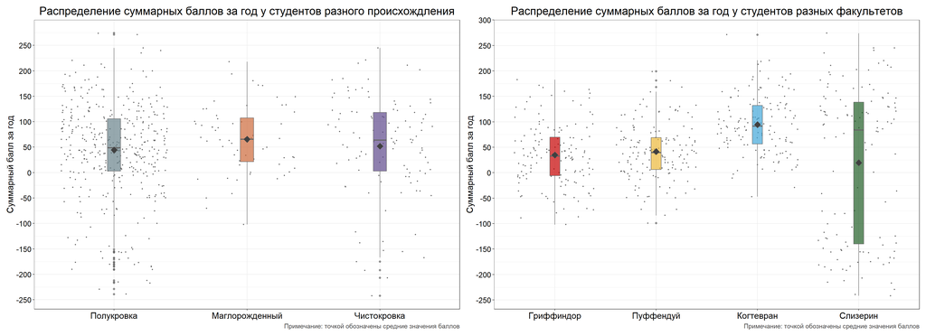

```r
hogwarts_resultmean_bloodStatus <- hogwarts %>%
  group_by(bloodStatus) %>%
  summarise(`Средний балл` = mean(result))

Hogwarts_result_bloodstatus <- hogwarts %>%
  ggplot(aes(x = bloodStatus, y = result))+
  geom_jitter(size = 0.7, shape = 21, colour = 'grey40', fill = 'grey40')+
  geom_boxplot(aes(fill =  bloodStatus), colour = 'grey40', width = 0.1, alpha = 0.7)+
  geom_point(data = hogwarts_resultmean_bloodStatus, aes(x = bloodStatus, y = `Средний балл`), size = 4, shape = 23, fill = 'grey25', colour = 'grey40')+
  labs(
    title = 'Распределение cуммарных баллов за год у студентов разного происхождления',
    x = NULL,
    y = 'Суммарный балл за год',
    caption = 'Примечание: точкой обозначены средние значения баллов'
  )+
  scale_fill_manual(values = bloodStatus_values)+
  scale_x_discrete(labels = bloodStatus_labels)+
  scale_y_continuous(breaks = seq(-250,300,50))+
  theme(
    plot.title = element_text(hjust = 0.5, size =19 ),
    axis.text.x = element_text(color = "black", size = 15),
    axis.text.y = element_text(color = "black", size = 13),
    axis.title = element_text(size = 15),
    legend.position = 'none',
    plot.caption = element_text(size = 11, colour = 'grey25'),

  )

hogwarts_resultmean_house <- hogwarts %>%
  group_by(house) %>%
  summarise(`Средний балл` = mean(result))

Hogwarts_result_house <- hogwarts %>%
  ggplot(aes(x = house, y = result))+
  geom_jitter(size = 0.7, shape = 21, colour = 'grey40', fill = 'grey40')+
  geom_boxplot(aes(fill = house), colour = 'grey40', width = 0.1, alpha = 0.7)+
  geom_point(data = hogwarts_resultmean_house, aes(x = house, y = `Средний балл`), size = 4, shape = 23, fill = 'grey25', colour = 'grey40')+
  labs(
    title = 'Распределение cуммарных баллов за год у студентов разных факультетов',
    x = NULL,
    y = 'Суммарный балл за год',
    caption = 'Примечание: точкой обозначены средние значения баллов'
  )+
  scale_fill_manual(values = house_colours)+
  scale_x_discrete(labels = house_names)+
  scale_y_continuous(breaks = seq(-250,300,50))+
  theme(
    plot.title = element_text(hjust = 0.5, size = 19 ),
    axis.text.x = element_text(color = "black", size = 15),
    axis.text.y = element_text(color = "black", size = 13),
    axis.title = element_text(size = 15),
    legend.position = 'none',
    plot.caption = element_text(size = 11, colour = 'grey25')
  )

Hogwarts_result_bloodstatus | Hogwarts_result_house
```

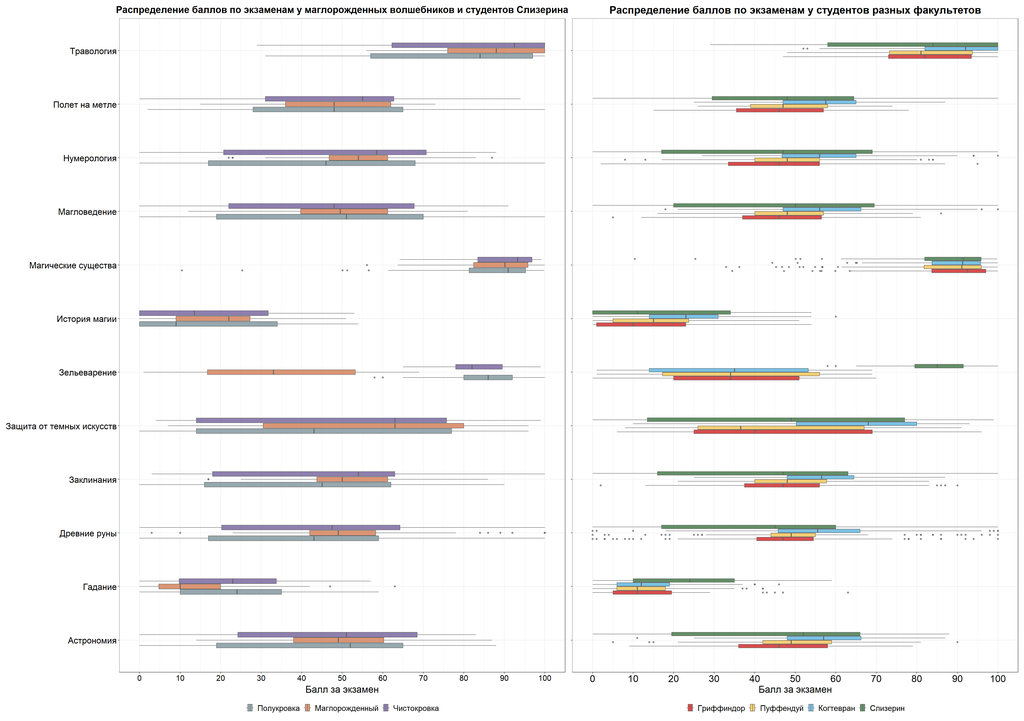

```r
Hogwarts_examsall_blood <- hogwarts %>%
  #фильтруем маглорожденных волшебников и чистокровных волшебников, учащихся слизарина
  filter(bloodStatus == 'muggle-born' | house == 'Slytherin') %>%
  select(id, bloodStatus, house, result, `Herbology exam`, `Muggle studies exam`, `Arithmancy exam`, `Potions exam`, `Defence against the dark arts exam`, `Flying exam`, `Astronomy exam`, `Divinations exam`, `Charms exam`, `History of magic exam`, `Study of ancient runes exam`, `Care of magical creatures exam`) %>%
  rename('Травология' = `Herbology exam`, 'Магловедение' = `Muggle studies exam`, 'Нумерология' = `Arithmancy exam`, 'Зельеварение'= `Potions exam`, 'Защита от темных искусств' = `Defence against the dark arts exam`, 'Полет на метле' = `Flying exam`, 'Астрономия' = `Astronomy exam`, 'Гадание' = `Divinations exam`, 'Заклинания' = `Charms exam`, 'История магии' = `History of magic exam`, 'Древние руны' = `Study of ancient runes exam`, 'Магические существа' = `Care of magical creatures exam`)  %>%
  pivot_longer(c('Травология', 'Магловедение', 'Нумерология', 'Зельеварение','Защита от темных искусств', 'Полет на метле', 'Астрономия', 'Гадание', 'Заклинания', 'История магии', 'Древние руны', 'Магические существа'), names_to = 'exams', values_to = 'score') %>%

  ggplot(aes(y = exams, x = score, fill = bloodStatus))+
  #geom_jitter(size = 0.7, shape = 21, colour = 'grey40', fill = 'grey40')+
  geom_boxplot(colour = 'grey40', width = 0.3, alpha = 0.7)+
  labs(
    title = 'Распределение баллов по экзаменам у маглорожденных волшебников и студентов Слизерина',
    y = NULL,
    x = 'Балл за экзамен'
  )+
  scale_fill_manual( name = NULL,
                    labels = bloodStatus_labels,
                    values = bloodStatus_values)+
  scale_x_continuous(breaks = seq(0,100,10))+
  theme(
    plot.title = element_text(hjust = 0.5, size =18, face = "bold"  ),
    axis.text.y = element_text(color = "black", size = 16.5),
    axis.text.x = element_text(color = "black", size = 15),
    axis.title = element_text(size = 18),
    plot.caption = element_text(size = 8, colour = 'grey25'),
    legend.position = 'bottom',
    legend.justification = 'centre',
    legend.direction = 'horizontal',
    legend.text = element_text(size = 15),
    legend.title = element_text(size = 15)
  )

Hogwarts_examsall_house <- hogwarts %>%
  select(id, bloodStatus, house, result, `Herbology exam`, `Muggle studies exam`, `Arithmancy exam`, `Potions exam`, `Defence against the dark arts exam`, `Flying exam`, `Astronomy exam`, `Divinations exam`, `Charms exam`, `History of magic exam`, `Study of ancient runes exam`, `Care of magical creatures exam`) %>%
  rename('Травология' = `Herbology exam`, 'Магловедение' = `Muggle studies exam`, 'Нумерология' = `Arithmancy exam`, 'Зельеварение'= `Potions exam`, 'Защита от темных искусств' = `Defence against the dark arts exam`, 'Полет на метле' = `Flying exam`, 'Астрономия' = `Astronomy exam`, 'Гадание' = `Divinations exam`, 'Заклинания' = `Charms exam`, 'История магии' = `History of magic exam`, 'Древние руны' = `Study of ancient runes exam`, 'Магические существа' = `Care of magical creatures exam`)  %>%
  pivot_longer(c('Травология', 'Магловедение', 'Нумерология', 'Зельеварение','Защита от темных искусств', 'Полет на метле', 'Астрономия', 'Гадание', 'Заклинания', 'История магии', 'Древние руны', 'Магические существа'), names_to = 'exams', values_to = 'score') %>%

  ggplot(aes(y = exams, x = score, fill = house))+
  #geom_jitter(size = 0.7, shape = 21, colour = 'grey40', fill = 'grey40')+
  geom_boxplot(colour = 'grey40', width = 0.3, alpha = 0.7)+
  labs(
    title = 'Распределение баллов по экзаменам у студентов разных факультетов',
    y = NULL,
    x = 'Балл за экзамен'
  )+
  scale_fill_manual( name = NULL,
                    labels = house_names,
                    values = house_colours)+
  scale_x_continuous(breaks = seq(0,100,10))+
  theme(
    plot.title = element_text(hjust = 0.5, size =20, face = "bold" ),
    axis.text.y = element_blank(),
    axis.text.x = element_text(color = "black", size = 18),
    axis.title = element_text(size = 18),
    plot.caption = element_text(size = 8, colour = 'grey25'),
    legend.position = 'bottom',
    legend.justification = 'centre',
    legend.direction = 'horizontal',
    legend.text = element_text(size = 15),
    legend.title = element_text(size = 15)
  )

Hogwarts_examsall_blood|Hogwarts_examsall_house
```

### 10. Претотвращение оверплоттинга. Взаимосвязь баллов за экзаменов по заклинаниям и по древним рунам

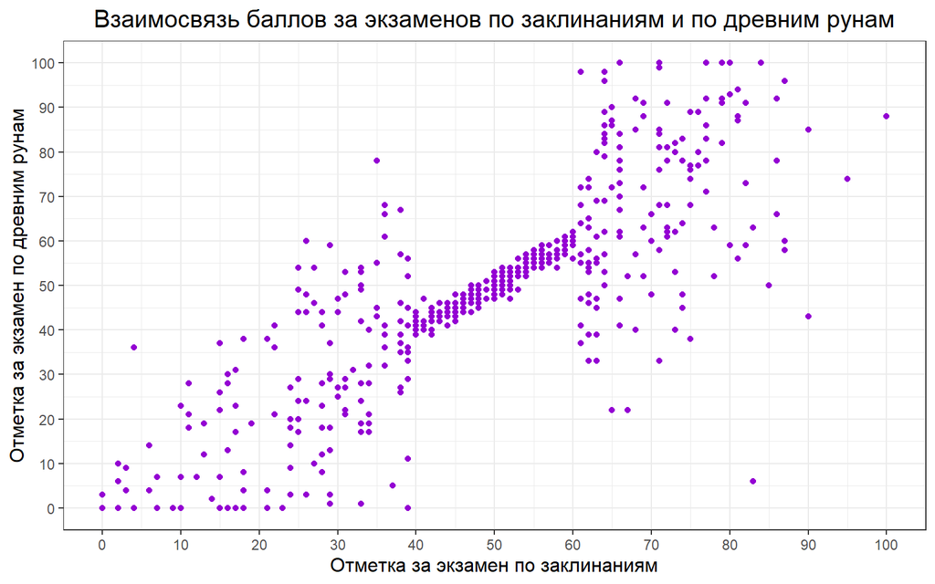

```r
#исходный график
hogwarts %>%
  ggplot()+
  geom_point(aes(x = `Charms exam`, y = `Study of ancient runes exam`), shape = 21, fill = 'darkviolet', colour = 'darkviolet')+
  labs(title = 'Взаимосвязь баллов за экзаменов по заклинаниям и по древним рунам',
       x = 'Отметка за экзамен по заклинаниям',
       y = 'Отметка за экзамен по древним рунам')+
  scale_y_continuous(breaks = seq(0,100,10))+
  scale_x_continuous(breaks = seq(0,100,10))+
  theme(
    plot.title = element_text(hjust = 0.5, size =15),
    axis.title = element_text(size = 12)
  )
```

```r
#смотрим подсказку
# podkazka <- read.csv("data/podskazka.csv")
#
# podkazka %>%
#   ggplot()+
#   geom_point(aes(x = y, y = x))+
#   scale_y_continuous(limits = c(200, 500))
```

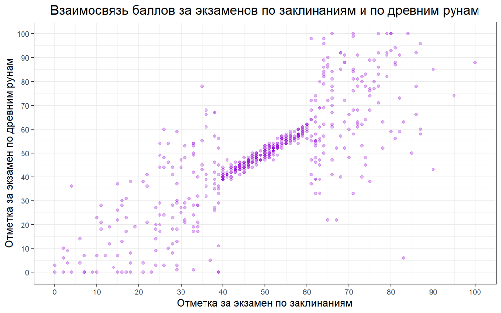

```r
#решение №1, использование прозрачности точек
#таким образом мы видим, что в метах бОльшей плотности точки накладываются друг на друга и выглядят темнее
hogwarts %>%
  ggplot()+
  geom_point(aes(x = `Charms exam`, y = `Study of ancient runes exam`), alpha = 0.3, shape = 21, fill = 'darkviolet', colour = 'darkviolet')+
  labs(title = 'Взаимосвязь баллов за экзаменов по заклинаниям и по древним рунам',
       x = 'Отметка за экзамен по заклинаниям',
       y = 'Отметка за экзамен по древним рунам')+
  scale_y_continuous(breaks = seq(0,100,10))+
  scale_x_continuous(breaks = seq(0,100,10))+
  theme(
    plot.title = element_text(hjust = 0.5, size =15),
    axis.title = element_text(size = 12)
  )
```

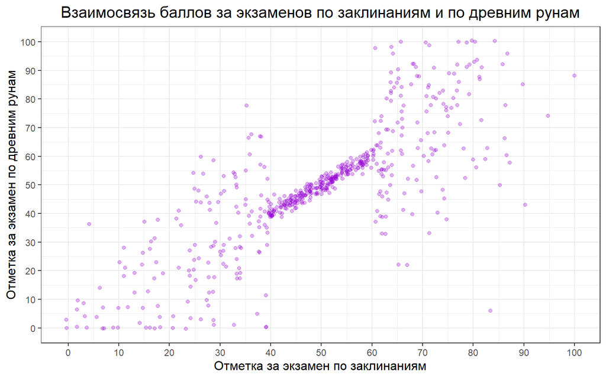

```r
#решение №2, сочетания прозрачности и position = position_jitter()
#position_jitter вносит некотрый шум на точки, что позволяет из разделить
#также в областях большей платноси видим более темные точки

hogwarts %>%
  ggplot()+
  geom_point(aes(x = `Charms exam`, y = `Study of ancient runes exam`), position = position_jitter(), alpha = 0.3, shape = 21, fill = 'darkviolet', colour = 'darkviolet')+
  labs(title = 'Взаимосвязь баллов за экзаменов по заклинаниям и по древним рунам',
       x = 'Отметка за экзамен по заклинаниям',
       y = 'Отметка за экзамен по древним рунам')+
  scale_y_continuous(breaks = seq(0,100,10))+
  scale_x_continuous(breaks = seq(0,100,10))+
  theme(
    plot.title = element_text(hjust = 0.5, size =15),
    axis.title = element_text(size = 12)
  )
```

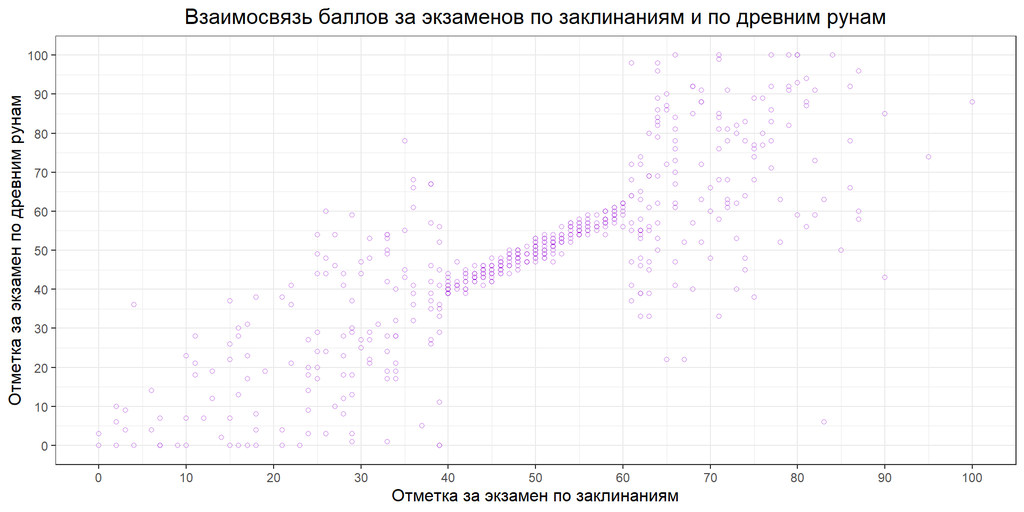

```r
#решение №3, использование пустотелых точек

hogwarts %>%
  ggplot(aes(x = `Charms exam`, y = `Study of ancient runes exam`))+
  geom_point(alpha = 0.5, size = 1.5, shape = 21, colour = 'darkviolet')+
  labs(title = 'Взаимосвязь баллов за экзаменов по заклинаниям и по древним рунам',
       x = 'Отметка за экзамен по заклинаниям',
       y = 'Отметка за экзамен по древним рунам')+
  scale_y_continuous(breaks = seq(0,100,10))+
  scale_x_continuous(breaks = seq(0,100,10))+
  theme(
    plot.title = element_text(hjust = 0.5, size =15),
    axis.title = element_text(size = 12)
  )
```

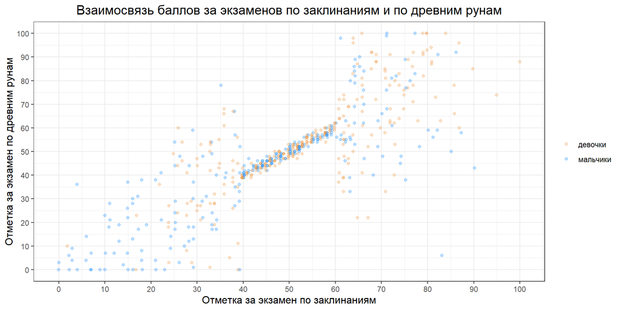

```r
#решение №4, сочетания прозрачности, разделения на группы и position = position_jitterdodge()
#в отличе от position = position_jitter, этот вариант дополнительно разводит точки
#разделение на группы и использование контрасных цветов позволяет в области оверплоттинга разделять вищуально больше точек

hogwarts %>%
  ggplot(aes(x = `Charms exam`, y = `Study of ancient runes exam`))+
  geom_point(aes(colour = sex), position = position_jitterdodge(), alpha = 0.3, size = 1.5)+
  labs(title = 'Взаимосвязь баллов за экзаменов по заклинаниям и по древним рунам',
       x = 'Отметка за экзамен по заклинаниям',
       y = 'Отметка за экзамен по древним рунам')+
  scale_colour_manual(name = NULL,
                    values = c(female = 'tan2',
                               male = 'dodgerblue'),
                    labels = c(male = 'мальчики', female = 'девочки')
                    )+
  scale_y_continuous(breaks = seq(0,100,10))+
  scale_x_continuous(breaks = seq(0,100,10))+
  theme(
    plot.title = element_text(hjust = 0.5, size =15),
    axis.title = element_text(size = 12)
  )
```

### 11. Изменение баллов первых 30 студентов в течение 40 недель

```r
first_30_students <- hogwarts |>
  filter(id <= 30) |>
  pivot_longer(c(starts_with("week")), names_to = "week_number", values_to = "score") |>
  mutate(week_number = week_number |> str_split_i("_", 2) |> as.numeric())
```

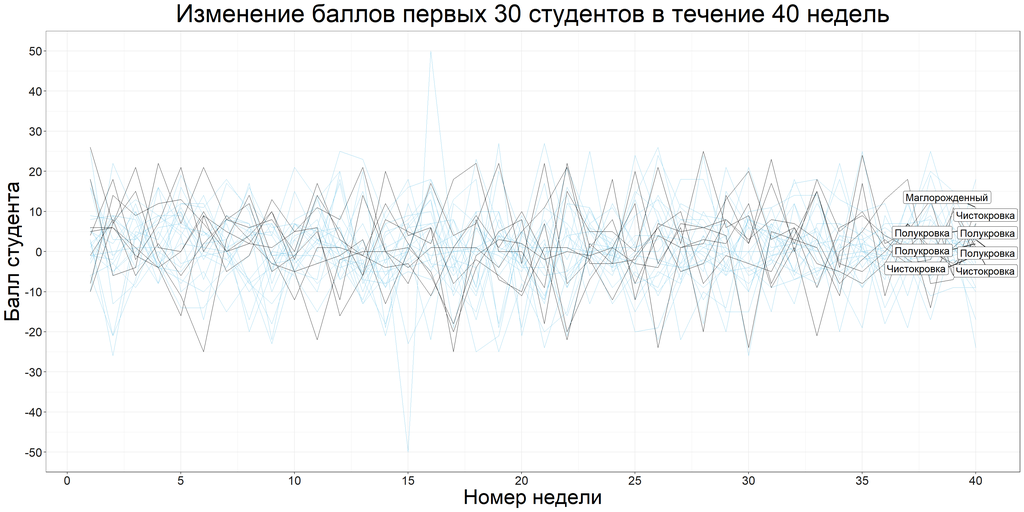

```r
first_30_students %>%
  mutate(id = as.factor(id), bloodStatus = fct_recode(factor(bloodStatus, labels = bloodStatus_labels))) %>%
  ggplot(aes(x = week_number, y = score, group = id))+
  geom_line(linewidth = 0.3)+
  gghighlight(house == 'Ravenclaw',
              label_key = bloodStatus,
              label_params = list(size = 5),
              unhighlighted_params = list(colour = 'skyblue', linewidth = 0.3))+
  labs(title = 'Изменение баллов первых 30 студентов в течение 40 недель',
       x = 'Номер недели',
       y = 'Балл студента')+
  scale_x_continuous(breaks = seq(0,40,5))+
  scale_y_continuous(breaks = seq(-50,50,10))+
  theme(
    plot.title = element_text(hjust = 0.5, size =35),
    axis.title = element_text(size = 29),
    axis.text = element_text(size = 17, colour = 'grey10'),
    legend.text = element_text(size = 25)
  )
```

### 12. Баллы студентов Хогвартса

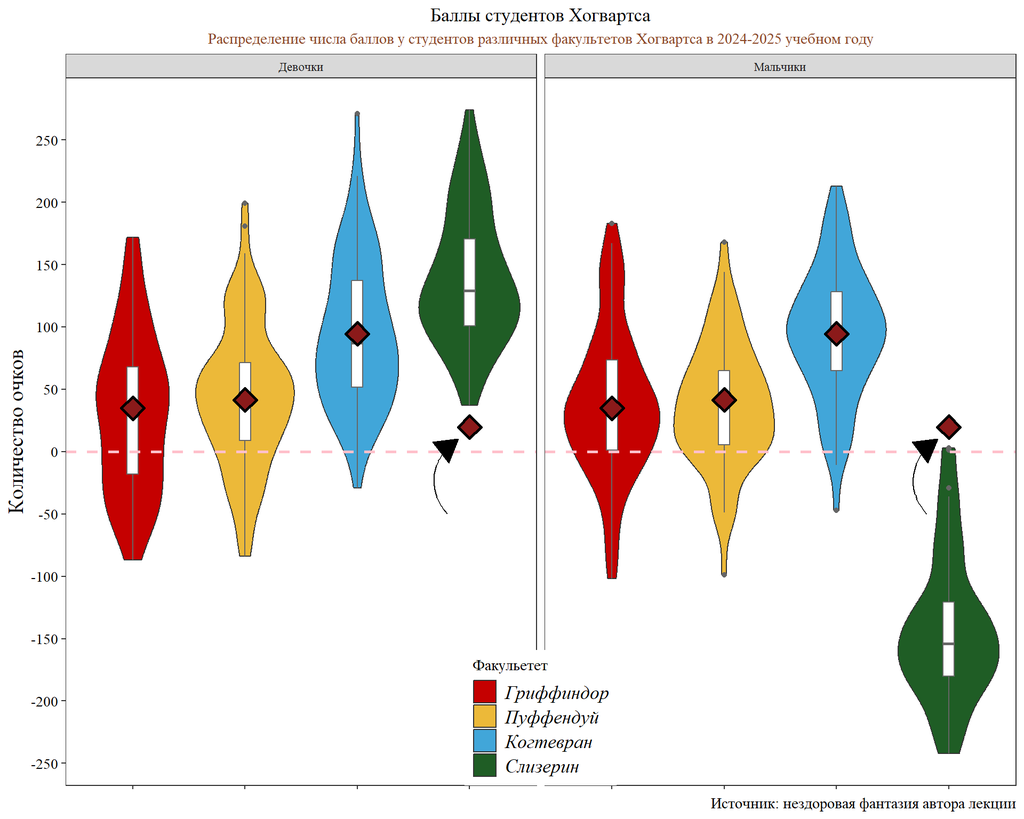

```r
#датафрейм для нанесения на график точек, соответсвующим средним значениям
house_mean_result <- hogwarts %>%
group_by(house) %>%
  summarise(`Средние по факультетам` = mean(result)) %>%
  ungroup()

hogwarts %>%
  ggplot()+
  #построение основного графика
  geom_violin(aes(x = house, y = result, fill = house))+
  facet_grid(.~sex, , labeller = labeller(sex = c('male' = 'Мальчики', 'female' = 'Девочки')))+
  #наслаиваем боксплот
  geom_boxplot(aes(x = house, y = result), width = 0.1, colour = 'grey40')+
  #наслаиваем точки, соответсвующие средним значениям + редактируем их формы и цвета
  geom_point(data = house_mean_result, aes(y = `Средние по факультетам`, x = house), shape = 23, size = 5, fill = 'firebrick4', colour = 'black', stroke = 1.5)+
  #настройка заголовков и подписей
  labs( title = 'Баллы студентов Хогвартса',
        subtitle = 'Распределение числа баллов у студентов различных факультетов Хогвартса в 2024-2025 учебном году',
        caption = 'Источник: нездоровая фантазия автора лекции',
        y = 'Количество очков',
        x = NULL
  )+
  #настройка легенды
  scale_fill_manual(
    name = 'Факульетет',
    values = house_colours,
    labels = house_names
  )+
  scale_y_continuous(breaks = seq(-250,250,50))+
  #наслаиваем линию
  geom_hline(yintercept = 0, linetype= 'dashed', colour = 'pink', linewidth = 1)+
  #рисуем стрелочку
  annotate(geom ='curve', x = 3.8, xend = 3.9, y = -50, yend = 10, arrow=arrow(type = 'closed'), curvature = -0.5)+
  theme(
    #настраиваем параметры легенды
    legend.text = element_text(face = "italic", size = 13),
    legend.position = 'inside',
    legend.justification = c('centre', 'bottom'),
    #задаем один шрифт на весь текст на графике, но у меня Times New Roman не работает :)
    text = element_text(family = "serif"),
    #настраиваем параметры заголовков и подписей
    plot.title = element_text(hjust = 0.5 ),
    plot.subtitle = element_text(hjust = 0.5, colour = 'sienna4'),
    plot.caption = element_text(size = 11),
    #настраиваем цвет и размер текста значений на оси у
    axis.text.y = element_text(color = "black", size = 10),
    #удяляем подпись оси х
    axis.text.x = element_blank(),
    #настраиваем размер подписи оси у и х
    axis.title = element_text(size = 15),
    #убираем все линии с графика
    panel.grid = element_blank()
    )
```

График описывает распределение баллов студентов-мальчиков и студентов-девочек разных факультетов.

Студенты мужского и женского пола факультета Когтевран получили баллы выше предыдущих двух факультетов. Распределение их баллов немного разнится, с диапазоном -25-270 и пологим распредлением для девочек и диапазоном -50-220 и пиком в районе среднего балла этого факультета (~100) для мальчиков.

Таким образом, наилучшую успеваимость имеют девочки-студенты Слизерина, за ними - студенты Когтеврана. Наименьшая успеваемость у мальчиков-студентов Слизерина.